# Module 8 Practice-Led

2025-11-03

# Module 8 Practice-Led

This Markdown is for Module 8 of MB5370. My specific project will be an organized markdown of my data analysis and visualization of my MMB Thesis project.

These are all of the libraries I used.

```r
library(ggplot2)
library(lme4)
library(MuMIn)
library(vegan)
library(emmeans)
library(lmerTest)
library(tibble)
library(plyr)
library(dplyr)
library(readr)
library(janitor)
library(pbkrtest)
library(tidyr)
library(ggpubr)
library(ggthemes)
library(stringr)
library(car)
library(glmmTMB)
library(nlme)
library(moments)
library(forcats)
library(ggpubr)
library(ggdist)
library(DHARMa)
library(ordinal)
```

#### Inputing Data

This is my data. I changed the developmental temperature, clutch ID and parental treatment variables to factors. Level order was established for the treatments for visualization purposes.

```r
Lat = read.csv("./Cognition-Behavior Testing.csv", strip.white=TRUE)
head(Lat)
```

```
##   Treatment Temperature Parent.Pair Clutch Tank.. Replicate L R Lat.Index
## 1       1.5        31.5         173  173.1      5         1 5 5         0
## 2       1.5        31.5         272  272.3      9         3 8 2       -60
## 3       1.5        31.5         272  272.3     10         5 7 3       -40
## 4       MHW        31.5         153  153.3     13         3 3 7        40
## 5       MHW        31.5         161  161.1     31         5 4 6        20
## 6   CONTROL        31.5         169  169.1     34         1 3 7        40
##   Abs.Lat.Index Used.in.learning Used.in.Boldness Ex.Tank Time.to.Emergence
## 1             0                                 x       1             14.29
## 2            60                                 x       1             26.59
## 3            40                x                x       1              0.01
## 4            40                                 x       1              0.51
## 5            20                                 x       1             21.45
## 6            40                                 x       1              3.58
##   Boldness                                   Boldness.Notes Emergence Time.Lost
```

[output cut: 20 more lines]

```r
Lat$Temperature = factor (Lat$Temperature)
Lat$Clutch = factor (Lat$Clutch)
Lat$Treatment = factor (Lat$Treatment)

level_order <- c('CONTROL', 'MHW', '1.5')
```

## Lateralization

The first trait I tested was lateralization. This trait was broken into directionally-dependent lateralization as well as absolute lateralization. The first thing I did was visualize both traits and graphed them on half-eye violin plots that were then combined.

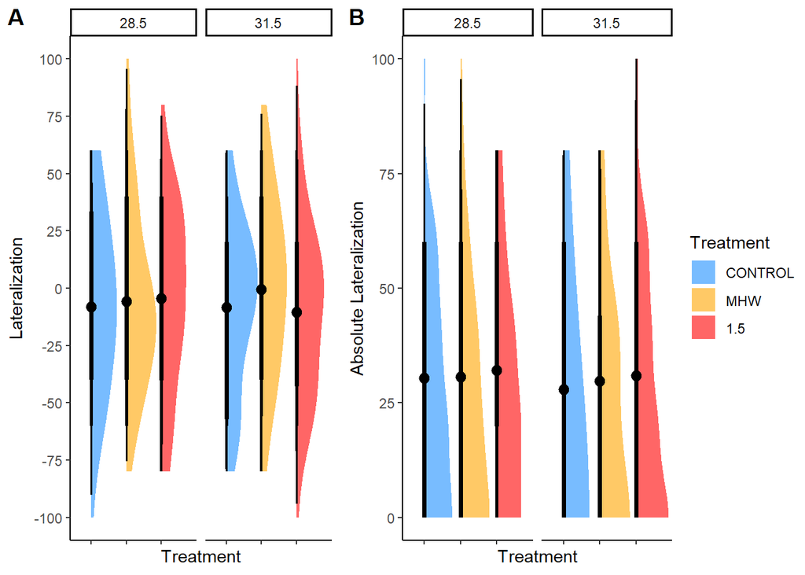

```r
lat <- ggplot(Lat, aes(x = Treatment, y = Lat.Index, fill = Treatment)) + stat_halfeye( .width = c(0.66, 0.89, 0.95, 0.99),  slab_alpha = 0.6,  point_interval = "mean_qi", position = position_dodge(width = 1)) + labs(x = "Treatment", y = "Lateralization") +  theme_classic() + facet_wrap(Lat$Temperature) + scale_y_continuous(breaks = seq(-100, 100, by = 25)) +
  scale_x_discrete(limits = level_order)  + scale_fill_manual(values = c('dodgerblue', 'orange', 'red'),
                   limits = c('CONTROL', 'MHW', '1.5')) + theme(axis.text.x = element_blank())

abslat <- ggplot(Lat, aes(x = Treatment, y = Abs.Lat.Index, fill = Treatment)) + stat_halfeye( .width = c(0.66, 0.89, 0.95, 0.99),  slab_alpha = 0.6,  point_interval = "mean_qi", position = position_dodge(width = 1), adjust = 3 ) + labs(x = "Treatment", y = "Absolute Lateralization") + theme_classic() + facet_wrap(Lat$Temperature) +
  scale_x_discrete(limits = level_order)  + scale_fill_manual(values = c('dodgerblue', 'orange', 'red'),
                   limits = c('CONTROL', 'MHW', '1.5')) + theme(axis.text.x = element_blank())




figure <- ggarrange(lat,abslat,
                    labels = c("A", "B"),
                    ncol = 2, widths = c(1, 1), common.legend = TRUE, legend = "right")
figure
```

```r
# ggsave("combined.png", figure, width = 12, height = 6, dpi = 250) this code fixes the sizing issue of the plots
```

## Directional-dependent lateralization

We tested this trait with multiple different glms and glmers. We found that Parent pair was singular and did not contribute to random effects. The gmler_latt with tank as a random effect was most fit.

```r
y <- cbind(Lat$L, Lat$R)

glm_Lat <- glm(y~ Treatment * Temperature , family = "binomial", data = Lat)

glmer_Lat <- glmer(y~ Treatment * Temperature + (1|Tank..) , family = "binomial", data = Lat)

glmer_Lat2 <- glmer(y~ Treatment * Temperature + (1|Parent.Pair/Tank..), family = "binomial", data = Lat)
```

```
## boundary (singular) fit: see help('isSingular')
```

```r
glmer_latt <- glmer(y~ Treatment + Temperature + (1|Tank..), family = "binomial", data = Lat)


AIC(glm_Lat, glmer_Lat, glmer_Lat2, glmer_latt)
```

```
##            df      AIC
## glm_Lat     6 1155.965
## glmer_Lat   7 1151.407
## glmer_Lat2  8 1153.407
## glmer_latt  5 1148.995
```

We tested with other family models but they were all similar so we kept the binomial model.

```r
glmer_Lat <- glmer(y~ Treatment * Temperature + (1|Tank..) , family = "binomial", data = Lat)
glmer_Lat3 <- glmer(y~ Treatment * Temperature + (1|Tank..) , family = binomial(link="probit"), data = Lat)
glmer_Lat4 <- glmer(y~ Treatment * Temperature + (1|Tank..) ,family = binomial(link="cloglog"), data = Lat)

AIC(glmer_Lat, glmer_Lat3, glmer_Lat4)
```

```
##            df      AIC
## glmer_Lat   7 1151.407
## glmer_Lat3  7 1151.394
## glmer_Lat4  7 1151.251
```

The model showed no significance from treatment and temperature.

```r
summary(glmer_latt)
```

```
## Generalized linear mixed model fit by maximum likelihood (Laplace
##   Approximation) [glmerMod]
##  Family: binomial  ( logit )
## Formula: y ~ Treatment + Temperature + (1 | Tank..)
##    Data: Lat
##
##       AIC       BIC    logLik -2*log(L)  df.resid
##    1149.0    1167.2    -569.5    1139.0       277
##
## Scaled residuals:
##      Min       1Q   Median       3Q      Max
## -2.70751 -0.79095 -0.05185  0.81226  2.32002
##
## Random effects:
##  Groups Name        Variance Std.Dev.
##  Tank.. (Intercept) 0.05096  0.2257
## Number of obs: 282, groups:  Tank.., 59
##
## Fixed effects:
##                  Estimate Std. Error z value Pr(>|z|)
## (Intercept)       0.15470    0.09461   1.635    0.102
## TreatmentCONTROL -0.01556    0.11569  -0.134    0.893
## TreatmentMHW     -0.07676    0.11789  -0.651    0.515
## Temperature31.5   0.01645    0.09642   0.171    0.865
##
## Correlation of Fixed Effects:
##             (Intr) TCONTR TrtMHW
## TrtmCONTROL -0.602
## TreatmntMHW -0.583  0.458
## Temprtr31.5 -0.553  0.062  0.046
```

```r
Anova(glmer_latt)
```

```
## Analysis of Deviance Table (Type II Wald chisquare tests)
##
## Response: y
##              Chisq Df Pr(>Chisq)
## Treatment   0.4579  2     0.7954
## Temperature 0.0291  1     0.8645
```

Even though there is some dispersion, this is the best model based on the data.

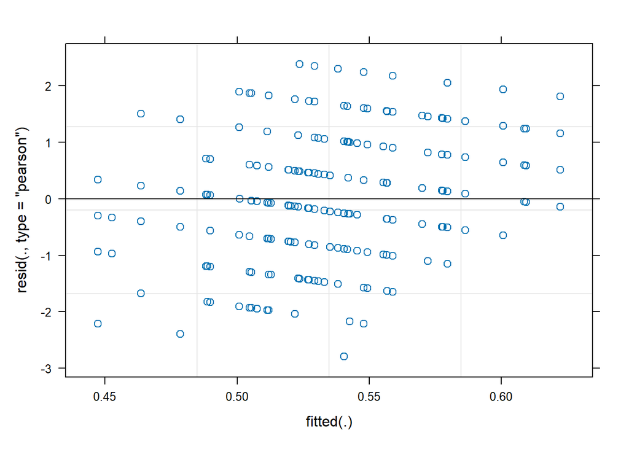

```r
plot(glmer_Lat)
```

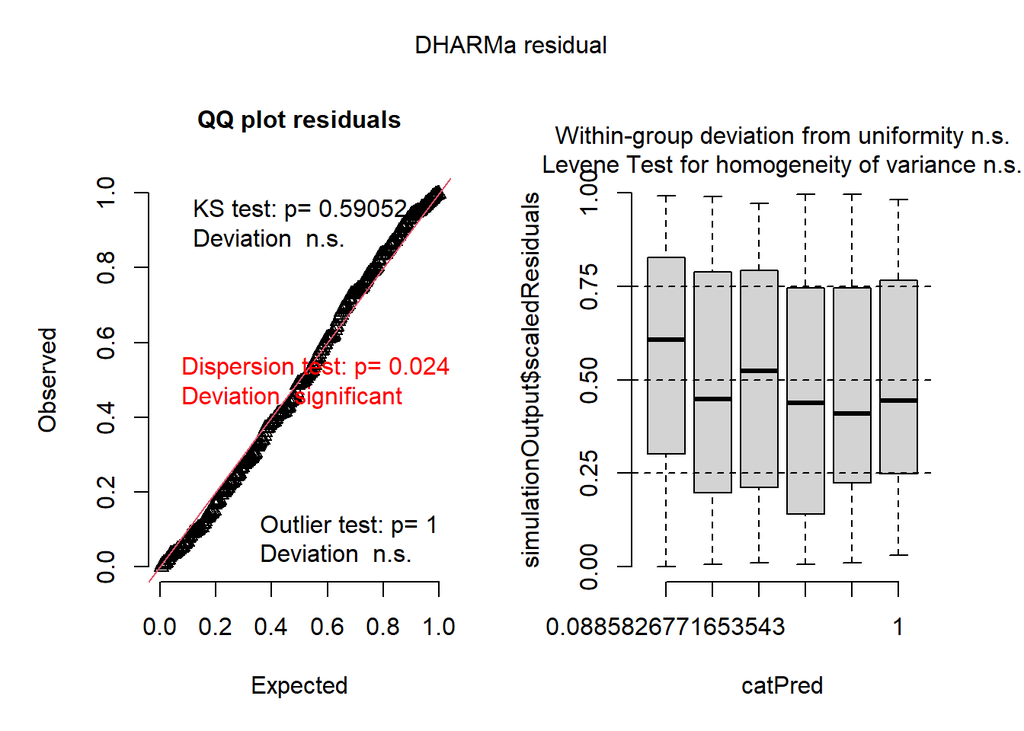

```r
plot(simulateResiduals(glmer_latt))
```

## Absolute lateralization

We used cumulative linked mixed models to model ordinal data such as the lateralization index.

```r
Lat$Abs.Lat.Index <- factor(Lat$Abs.Lat.Index,
                       levels = c(0, 20, 40, 60, 80, 100),
                       ordered = TRUE) #changing Abs.Lat.Index score to factor #changing Abs.Lat.Index score to factor

Model_abslat <- clmm(Abs.Lat.Index ~ Treatment * Temperature + (1|Parent.Pair) + (1|Tank..), data = Lat)
```

Interaction showed no effect.

```r
abslat_1 <- clmm(Abs.Lat.Index ~ Treatment:Temperature + Treatment + Temperature + (1|Parent.Pair) + (1|Tank..), data = Lat)
abslat_2 <- clmm(Abs.Lat.Index ~ Treatment + Temperature + (1|Parent.Pair) + (1|Tank..), data = Lat)
anova(abslat_1, abslat_2)
```

```
## Likelihood ratio tests of cumulative link models:
##
##          formula:
## abslat_2 Abs.Lat.Index ~ Treatment + Temperature + (1 | Parent.Pair) + (1 | Tank..)
## abslat_1 Abs.Lat.Index ~ Treatment:Temperature + Treatment + Temperature + (1 | Parent.Pair) + (1 | Tank..)
##          link: threshold:
## abslat_2 logit flexible
## abslat_1 logit flexible
##
##          no.par    AIC  logLik LR.stat df Pr(>Chisq)
## abslat_2     10 888.02 -434.01
## abslat_1     12 891.98 -433.99  0.0417  2     0.9793
```

Abslat_4 was the best fit.

```r
abslat_3 <- clmm(Abs.Lat.Index ~ Treatment + Temperature + (1|Parent.Pair) , data = Lat)
abslat_4 <- clmm(Abs.Lat.Index ~ Treatment + Temperature + (1|Tank..) , data = Lat)
abslat_5 <- clm(Abs.Lat.Index ~ Treatment + Temperature, data = Lat)
AIC(abslat_1, abslat_2, abslat_3, abslat_4, abslat_5)
```

```
##          df      AIC
## abslat_1 12 891.9815
## abslat_2 10 888.0233
## abslat_3  9 889.7576
## abslat_4  9 886.0305
## abslat_5  8 887.7576
```

```r
Anova(abslat_4)
```

```
## Analysis of Deviance Table (Type II tests)
##
## Response: Abs.Lat.Index
##             Df  Chisq Pr(>Chisq)
## Treatment    2 0.2482     0.8833
## Temperature  1 0.3540     0.5518
```

```r
nominal_test(abslat_5)
```

```
## Tests of nominal effects
##
## formula: Abs.Lat.Index ~ Treatment + Temperature
##             Df  logLik    AIC    LRT Pr(>Chi)
## <none>         -435.88 887.76
## Treatment    8 -432.95 897.91 5.8499   0.6640
## Temperature  4 -435.44 894.88 0.8823   0.9271
```

# Boldness

Boldness was measured with boldness score, emergence and time of emergence. First, we ran visualizations for all three traits.

```r
Lat <- Lat %>% mutate(Emerge = if_else(Emergence == "Non emerge", 0, 1))

Lat %>% group_by(Treatment, Temperature, Parent.Pair) %>%
  summarise(n_0 = sum(Emerge == 0, na.rm = TRUE),
    n_1 = sum(Emerge == 1, na.rm = TRUE))
```

```
## # A tibble: 21 × 5
## # Groups:   Treatment, Temperature [6]
##    Treatment Temperature Parent.Pair   n_0   n_1
##    <fct>     <fct>             <int> <int> <int>
##  1 1.5       28.5                173     3     6
##  2 1.5       28.5                255     1     4
##  3 1.5       28.5                259     7    13
##  4 1.5       28.5                272     0    15
##  5 1.5       31.5                155     1     4
##  6 1.5       31.5                173     4     6
##  7 1.5       31.5                255     0     5
##  8 1.5       31.5                259    11     9
##  9 1.5       31.5                272     3    16
## 10 CONTROL   28.5                169     1     9
## # ℹ 11 more rows
```

```r
Lat %>% select(Time.to.Emergence)
```

[output not shown]

[output cut: 273 more lines]

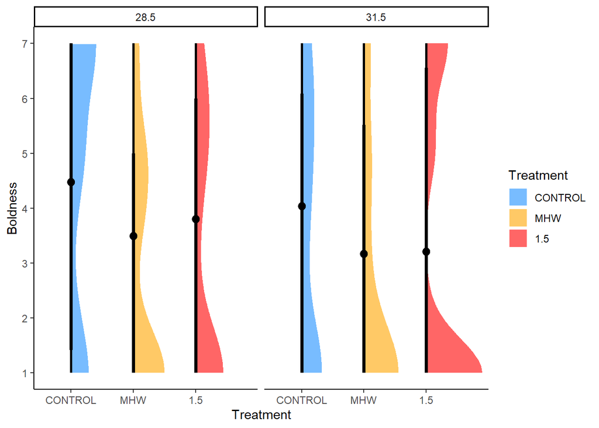

```r
df <- Lat[!is.na(Lat$Emergence),]


df$Emergence <- factor(df$Emergence, levels = c("Non emerge", "Emerge"))


ggplot(df, aes(x = Treatment, y = Boldness, fill = Treatment)) + stat_halfeye( .width = c(0.66, 0.89, 0.95, 0.99),  slab_alpha = 0.6,  point_interval = "mean_qi", position = position_dodge(width = 1)) + labs(x = "Treatment", y = "Boldness") +  theme_classic() + facet_wrap(df$Temperature) + scale_y_continuous(breaks = seq(1, 7, by = 1)) +
  scale_x_discrete(limits = level_order) + scale_fill_manual(values = c('dodgerblue', 'orange', 'red'),
                   limits = level_order)
```

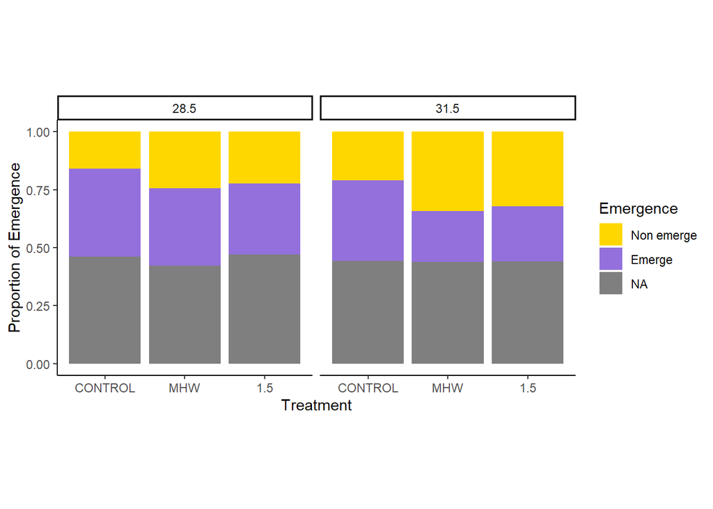

```r
emerge <- ggplot(df, aes(x=Treatment, fill= Emergence)) +
    geom_bar(position = "fill") +
  coord_cartesian(ylim = c(0, 1)) +
  facet_wrap(~Temperature) + labs( y = "Proportion of Emergence") +
  theme_classic()  +
   scale_x_discrete(limits = level_order) +
  scale_fill_manual(values = c('gold', 'mediumpurple')) + theme(aspect.ratio = 1)

emerge
```

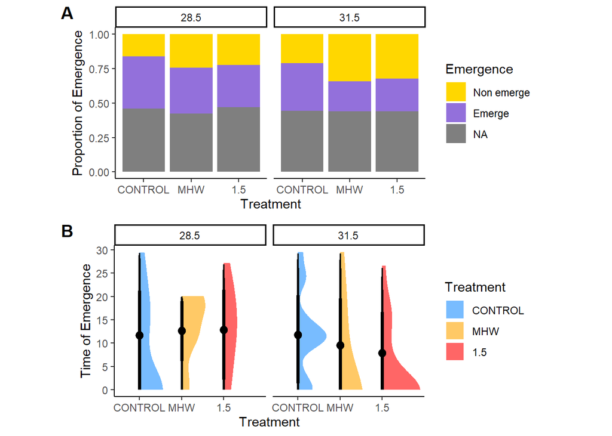

```r
ToEgraph <- ggplot(df, aes(x = Treatment, y = Time.to.Emergence, fill = Treatment)) + stat_halfeye( .width = c(0.66, 0.89, 0.95, 0.99),  slab_alpha = 0.6,  point_interval = "mean_qi", position = position_dodge(width = 1)) + labs( y = "Time of Emergence") +  theme_classic() +  facet_wrap(df$Temperature) + scale_y_continuous(breaks = seq(0, 30, by = 5)) +
  scale_x_discrete(limits = level_order)  + scale_fill_manual(values = c('dodgerblue', 'orange', 'red'),
                   limits = c('CONTROL', 'MHW', '1.5'))  + theme(aspect.ratio = 1)

emergencefigure <- ggarrange(emerge,ToEgraph,
                    labels = c("A", "B"),
                    nrow  = 2, label.x = 0.09)
emergencefigure
```

```r
# ggsave("emergencefig.png", emergencefigure, width = 10, height = 8)
```

## Boldness Score

The boldness score was turned into an ordinal factor and then models were run.

```r
Lat$Boldness <- factor(Lat$Boldness,
                       levels = 1:7,
                       labels = c(1, 2, 3, 4, 5, 6, 7),
                       ordered = TRUE) #changing Boldness score to factor

Model_bold <- clmm(Boldness ~ Treatment * Temperature + (1|Parent.Pair) + (1|Tank..), data = Lat)
```

Here, we ran an anova between two cumulative linked mixed models to check if the two fixed factors had an interaction.

```r
bold1 <- clmm(Boldness ~ Treatment:Temperature + Treatment + Temperature + (1|Parent.Pair) + (1|Tank..), data = Lat)
bold2 <- clmm(Boldness ~ Treatment + Temperature + (1|Parent.Pair) + (1|Tank..), data = Lat)
anova(bold1,bold2)
```

```
## Likelihood ratio tests of cumulative link models:
##
##       formula:
## bold2 Boldness ~ Treatment + Temperature + (1 | Parent.Pair) + (1 | Tank..)
## bold1 Boldness ~ Treatment:Temperature + Treatment + Temperature + (1 | Parent.Pair) + (1 | Tank..)
##       link: threshold:
## bold2 logit flexible
## bold1 logit flexible
##
##       no.par    AIC  logLik LR.stat df Pr(>Chisq)
## bold2     11 560.00 -269.00
## bold1     13 563.63 -268.81  0.3734  2     0.8297
```

There was no interaction so we tested the fixed factors individually. Each model was compared using AIC to determine the best fit.

```r
bold3 <- clmm(Boldness ~ Treatment + Temperature + (1|Parent.Pair) , data = Lat)
bold4 <- clmm(Boldness ~ Treatment + Temperature + (1|Tank..) , data = Lat)
bold5 <- clm(Boldness ~ Treatment + Temperature, data = Lat)
AIC(bold1, bold2, bold3, bold4, bold5)
```

```
##       df      AIC
## bold1 13 563.6280
## bold2 11 560.0014
## bold3 10 558.0936
## bold4 10 560.7411
## bold5  9 559.5599
```

The model showed no significance from treatment and temperature. We tested the assumption using the nominal test function, however those do not work on mixed models so we used the closest clm which was bold5.

```r
Anova(bold3)
```

```
## Analysis of Deviance Table (Type II tests)
##
## Response: Boldness
##             Df  Chisq Pr(>Chisq)
## Treatment    2 1.8765     0.3913
## Temperature  1 2.4551     0.1171
```

```r
nominal_test(bold5)
```

```
## Tests of nominal effects
##
## formula: Boldness ~ Treatment + Temperature
##             Df  logLik    AIC     LRT Pr(>Chi)
## <none>         -270.78 559.56
## Treatment   10 -264.90 567.79 11.7677   0.3009
## Temperature  5 -267.57 563.14  6.4208   0.2674
```

## Time to Emergence

We tested various models to look at Time of emergence. The Zi gamma distribition zig_TOE4 was best fit.

```r
lm_ToE <- lm(Time.to.Emergence ~ Treatment * Temperature , data = Lat)
lmer_ToE <- lmer(Time.to.Emergence ~Treatment * Temperature + (1|Tank..), data = Lat)
```

```
## boundary (singular) fit: see help('isSingular')
```

```r
lmer_ToE2 = lmer(Time.to.Emergence ~ Treatment * Temperature + (1|Parent.Pair), data = Lat)
```

```
## boundary (singular) fit: see help('isSingular')
```

```r
zig_ToE3 <- glmmTMB(Time.to.Emergence ~Treatment * Temperature ,  ziformula = ~1, family = ziGamma(link = "log"), data = Lat)
zig_ToE4 <- glmmTMB(Time.to.Emergence ~Treatment + Temperature ,  ziformula = ~1, family = ziGamma(link = "log"), data = Lat)
zig_ToE <- glmmTMB(Time.to.Emergence ~Treatment * Temperature + (1|Tank..),  ziformula = ~1, family = ziGamma(link = "log"), data = Lat)
zig_ToE2 <- glmmTMB(Time.to.Emergence ~Treatment * Temperature + (1|Parent.Pair/Tank..),  ziformula = ~1, family = ziGamma(link = "log"), data = Lat)

AIC(lm_ToE, lmer_ToE, lmer_ToE2, zig_ToE, zig_ToE2, zig_ToE3, zig_ToE4)
```

```
##           df      AIC
## lm_ToE     7 640.1817
## lmer_ToE   8 620.6898
## lmer_ToE2  8 620.6898
## zig_ToE    9 615.3111
## zig_ToE2  10 617.3111
## zig_ToE3   8 613.3111
## zig_ToE4   6 609.9667
```

Treatment and temperature did not have an effect on Time of Emergence.

```r
Anova(zig_ToE4)
```

```
## Analysis of Deviance Table (Type II Wald chisquare tests)
##
## Response: Time.to.Emergence
##              Chisq Df Pr(>Chisq)
## Treatment   0.6825  2     0.7109
## Temperature 0.5031  1     0.4781
```

Distribution is not normal for ZIG distribution anyways, the issues are expected.

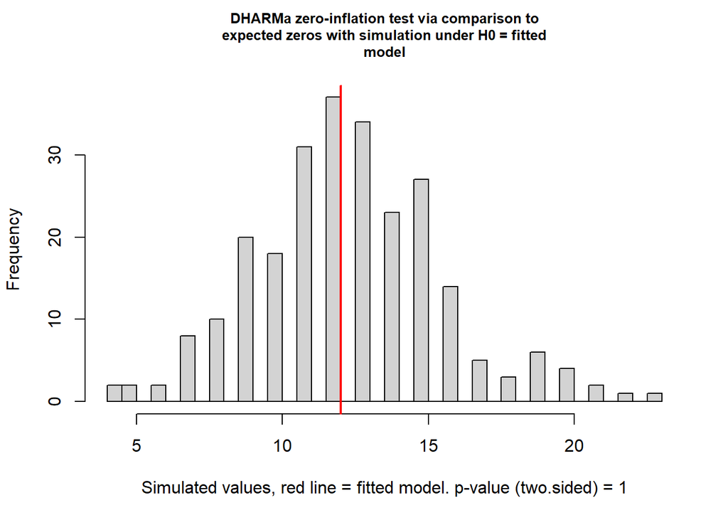

```
##
##  DHARMa zero-inflation test via comparison to expected zeros with
##  simulation under H0 = fitted model
##
## data:  simulationOutput
## ratioObsSim = 0.96031, p-value = 1
## alternative hypothesis: two.sided
```

```r
library(DHARMa)
res <- simulateResiduals(zig_ToE4)
testZeroInflation(res)
```

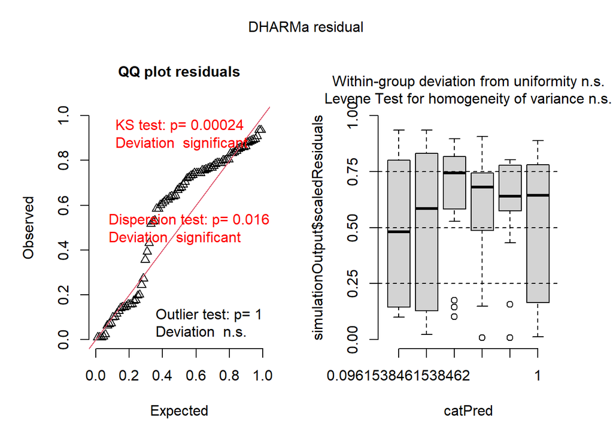

```r
plot(res)
```

## Emergence

To test for Emergence rates.

```r
glm_Emerge <- glm(Emerge~ Treatment * Temperature , family = "binomial", data = Lat)

glm_Emerge2 <- glm(Emerge~ Treatment + Temperature , family = "binomial", data = Lat)

glmer_Emerge <- glmer(Emerge~ Treatment + Temperature + (1|Tank..) , family = "binomial", data = Lat)
```

```
## boundary (singular) fit: see help('isSingular')
```

```r
glmer_Emerge2 <- glmer(Emerge~ Treatment + Temperature + (1|Parent.Pair), family = "binomial", data = Lat)

glmer_Emerge3 <- glmer(Emerge~ Treatment * Temperature + (1|Tank..) , family = "binomial", data = Lat)
```

```
## boundary (singular) fit: see help('isSingular')
```

```r
glmer_Emerge4 <- glmer(Emerge~ Treatment * Temperature + (1|Parent.Pair), family = "binomial", data = Lat)

AIC(glm_Emerge, glm_Emerge2,glmer_Emerge, glmer_Emerge2, glmer_Emerge3, glmer_Emerge4)
```

```
##               df      AIC
## glm_Emerge     6 329.1237
## glm_Emerge2    4 325.1861
## glmer_Emerge   5 327.1861
## glmer_Emerge2  5 324.8348
## glmer_Emerge3  7 331.1237
## glmer_Emerge4  7 328.7363
```

```r
Anova(glmer_Emerge2)
```

```
## Analysis of Deviance Table (Type II Wald chisquare tests)
##
## Response: Emerge
##              Chisq Df Pr(>Chisq)
## Treatment   1.8608  2     0.3944
## Temperature 2.9106  1     0.0880 .
## ---
## Signif. codes:  0 '***' 0.001 '**' 0.01 '*' 0.05 '.' 0.1 ' ' 1
```

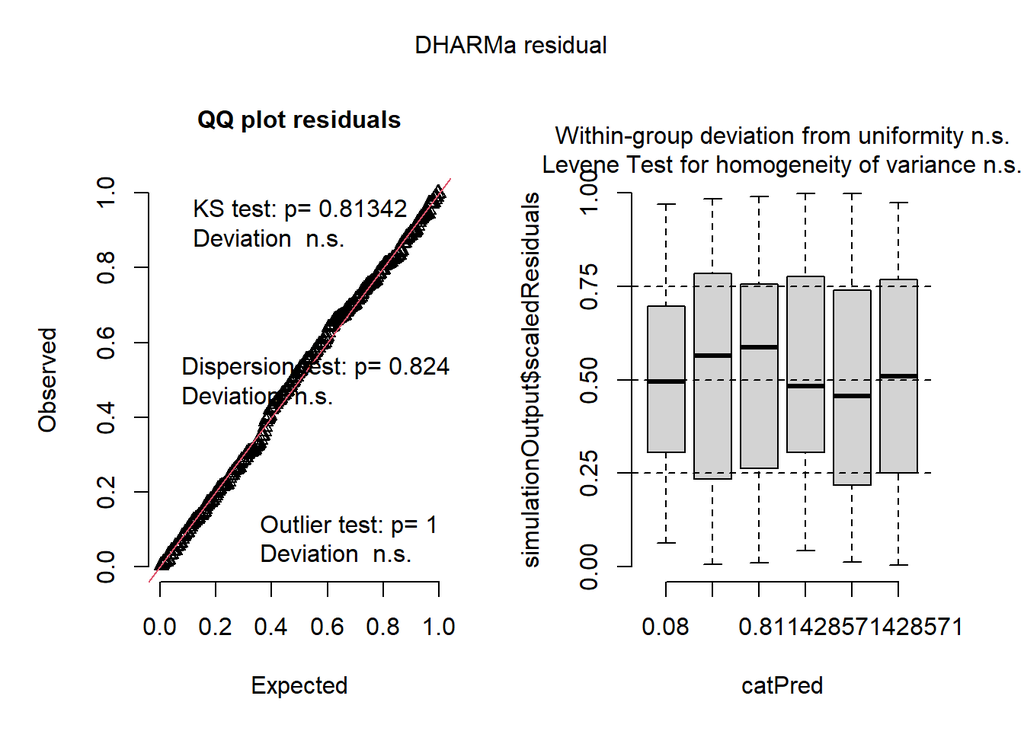

```r
res <- simulateResiduals(glmer_Emerge2)
plot(res)
```

# Activity

We tested exploration and time spent moving in order to look at activity in the fish. First, We created a combined half-eye violin plot to visualize the data.

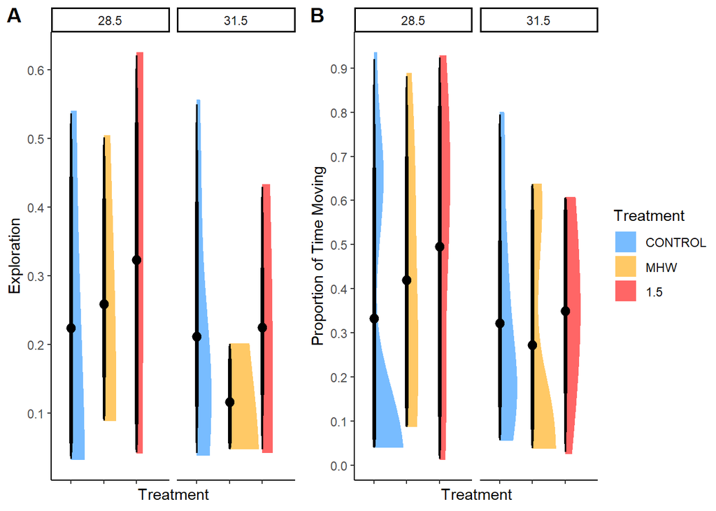

```r
exploration <- ggplot(Lat, aes(x = Treatment, y = Exploration, fill = Treatment)) + stat_halfeye( .width = c(0.66, 0.89, 0.95, 0.99),  slab_alpha = 0.6,  point_interval = "mean_qi", position = position_dodge(width = 1), adjust = 3) + labs( y = "Exploration") +  theme_classic() + facet_wrap(Lat$Temperature) + scale_y_continuous(breaks = seq(0, 1, by = 0.1)) +
  scale_x_discrete(limits = level_order)  + scale_fill_manual(values = c('dodgerblue', 'orange', 'red'),
                   limits = c('CONTROL', 'MHW', '1.5')) + theme(axis.text.x = element_blank())

Timemove <- ggplot(Lat, aes(x = Treatment, y = Calc.move, fill = Treatment)) + stat_halfeye( .width = c(0.66, 0.89, 0.95, 0.99),  slab_alpha = 0.6,  point_interval = "mean_qi", position = position_dodge(width = 1)) + labs(x = "Treatment", y = "Proportion of Time Moving") +  theme_classic() + facet_wrap(Lat$Temperature) + scale_y_continuous(breaks = seq(0, 1, by = 0.1)) +
  scale_x_discrete(limits = level_order)  + scale_fill_manual(values = c('dodgerblue', 'orange', 'red'),
                   limits = c('CONTROL', 'MHW', '1.5')) + theme(axis.text.x = element_blank())

activityfigure <- ggarrange(exploration,Timemove,
                    labels = c("A", "B"),
                    ncol = 2, widths = c(1, 1), common.legend = TRUE, legend = "right")
activityfigure
```

```r
## ggsave("activityfig.png", activityfigure, width = 12, height = 6, dpi = 250)
```

## Exploration

We tested various models and found lm_Exp2 had the best fit.

```r
lm_Exp <- lm(Exploration ~ Treatment * Temperature , data = Lat)
lmer_Exp <- lmer(Exploration ~Treatment * Temperature + (1|Tank..), data = Lat)
lmer_Exp2 <- lmer(Exploration ~ Treatment * Temperature + (1|Parent.Pair), data = Lat)
lmer_Exp3 <- lmer(Exploration ~ Treatment * Temperature + (1|Parent.Pair/Tank..), data = Lat)
lm_Exp2 <- lm(Exploration ~ Treatment + Temperature , data = Lat)

AIC(lm_Exp, lmer_Exp, lmer_Exp2, lmer_Exp3, lm_Exp2)
```

```
##           df       AIC
## lm_Exp     7 -63.55114
## lmer_Exp   8 -34.77764
## lmer_Exp2  8 -37.48987
## lmer_Exp3  9 -35.49170
## lm_Exp2    5 -65.13432
```

This model shows significance from developmental temperature.

```r
Anova(lm_Exp2)
```

```
## Anova Table (Type II tests)
##
## Response: Exploration
##              Sum Sq Df F value  Pr(>F)
## Treatment   0.08616  2  1.7880 0.17425
## Temperature 0.12292  1  5.1015 0.02677 *
## Residuals   1.83120 76
## ---
## Signif. codes:  0 '***' 0.001 '**' 0.01 '*' 0.05 '.' 0.1 ' ' 1
```

We tested the model and there were no significant issues.

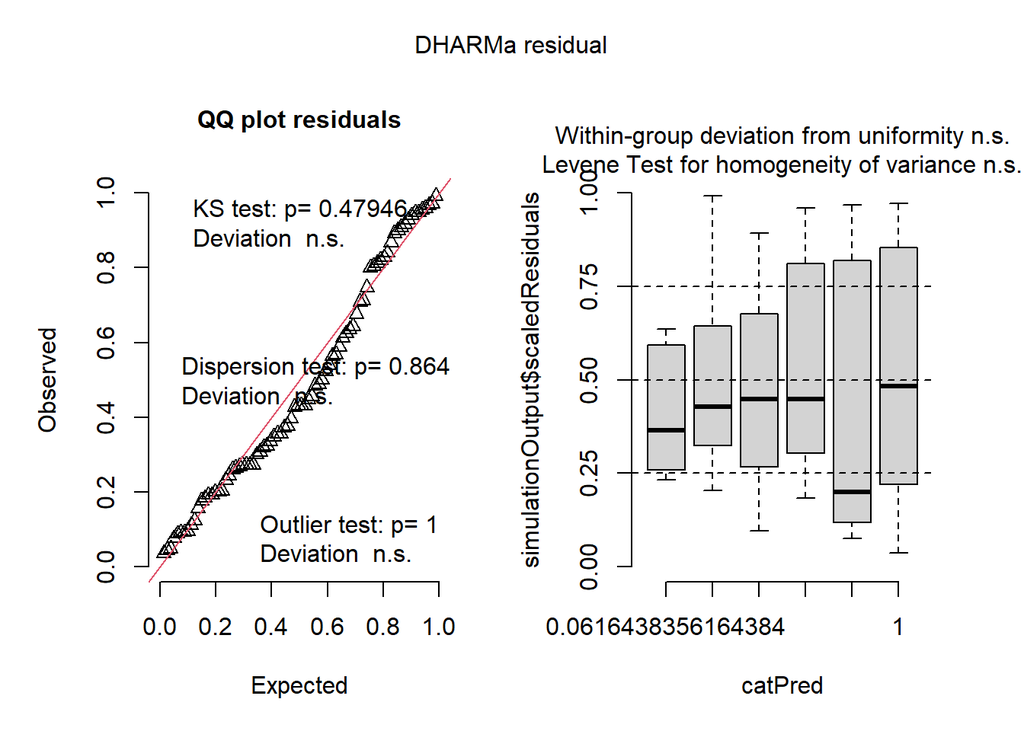

```r
res <- simulateResiduals(lm_Exp2)
plot(res)
```

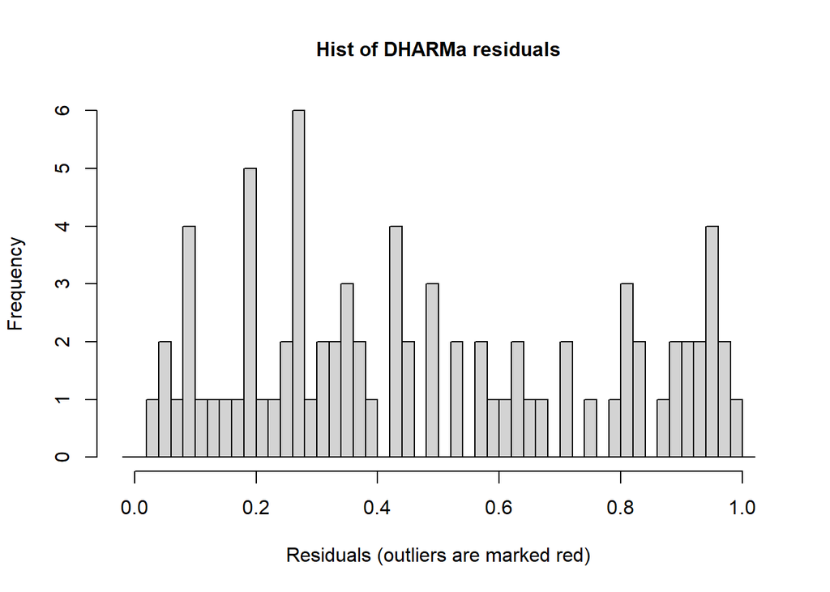

```r
hist(res)
```

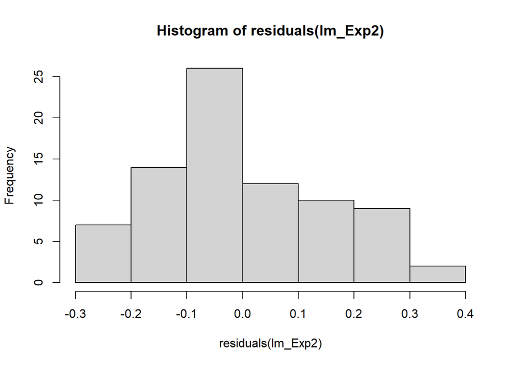

```r
hist(residuals(lm_Exp2))
```

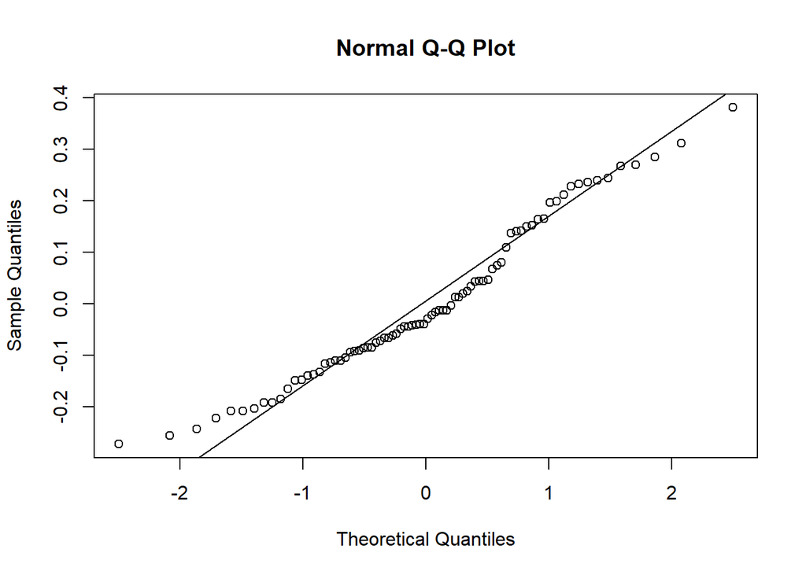

```r
qqnorm(residuals(lm_Exp2)); qqline(residuals(lm_Exp2))
```

## Time moving

LM2 had the lowest AIC. There are no random effects.

```r
lm_Mov <- lm(Calc.move ~ Treatment * Temperature , data = Lat)
lmer_Mov <- lmer(Calc.move ~Treatment * Temperature + (1|Tank..), data = Lat)
```

```
## boundary (singular) fit: see help('isSingular')
```

```r
lmer_Mov2 = lmer(Calc.move ~ Treatment * Temperature + (1|Parent.Pair), data = Lat)
lmer_Mov3 = lmer(Calc.move ~ Treatment * Temperature + (1|Parent.Pair/Tank..), data = Lat)
```

```
## boundary (singular) fit: see help('isSingular')
```

```r
lm_Mov2 <- lm(Calc.move ~ Treatment + Temperature , data = Lat)

AIC(lm_Mov, lmer_Mov, lmer_Mov2, lmer_Mov3, lm_Mov2)
```

```
##           df      AIC
## lm_Mov     7 24.60898
## lmer_Mov   8 46.99006
## lmer_Mov2  8 45.57764
## lmer_Mov3  9 47.57764
## lm_Mov2    5 21.84671
```

This model shows no significance.

```r
Anova(lm_Mov2)
```

```
## Anova Table (Type II tests)
##
## Response: Calc.move
##             Sum Sq Df F value Pr(>F)
## Treatment   0.1471  2  1.0290 0.3623
## Temperature 0.1857  1  2.5983 0.1111
## Residuals   5.4316 76
```

We tested the model and there were no significant issues.

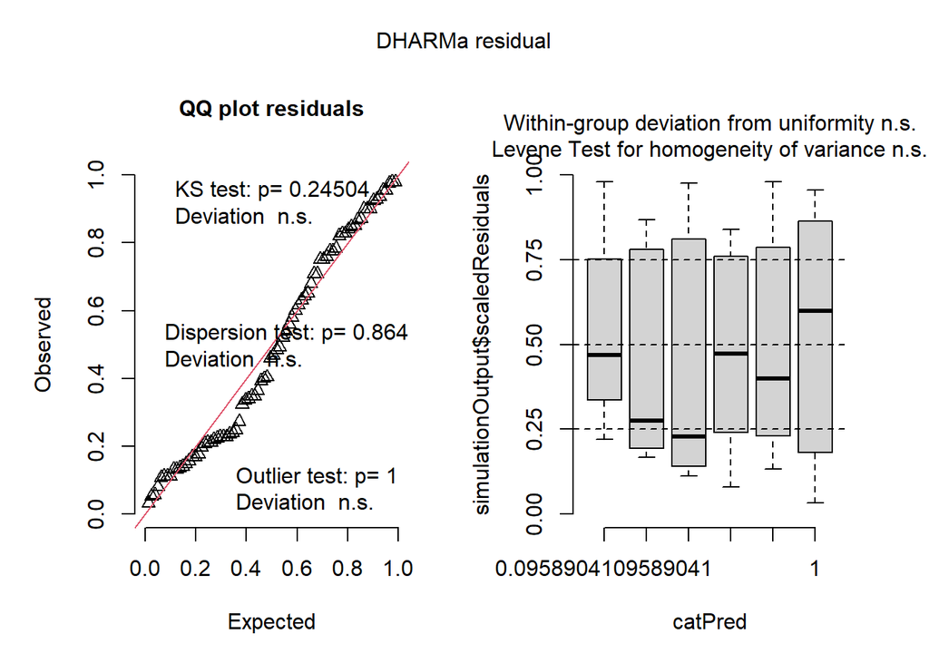

```r
library(DHARMa)
res <- simulateResiduals(lm_Mov2)
plot(res)
```

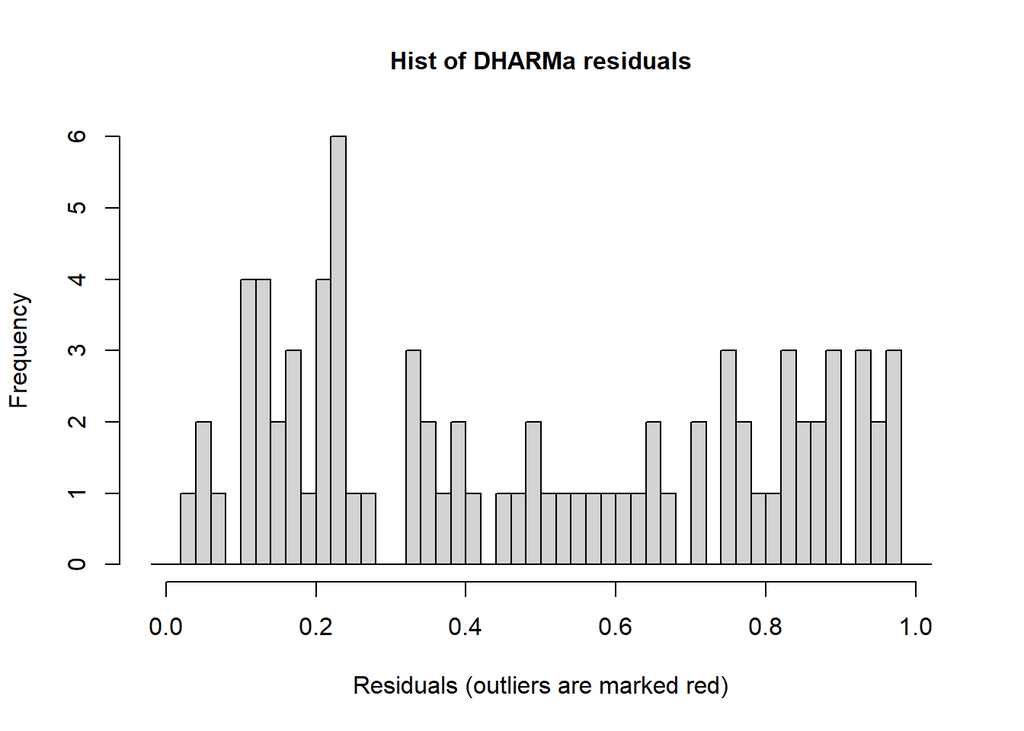

```r
hist(res)
```

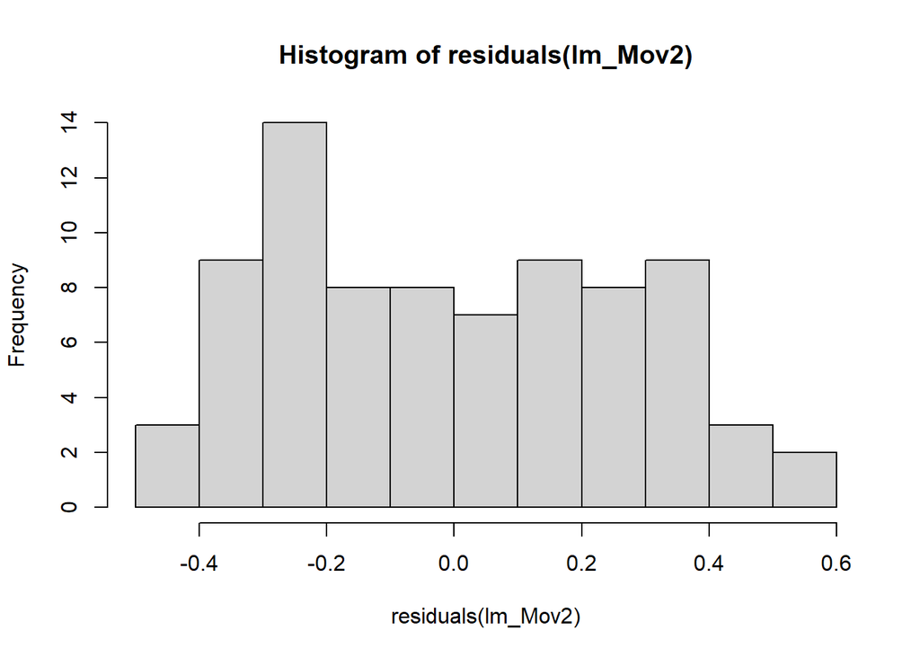

```r
hist(residuals(lm_Mov2))
```

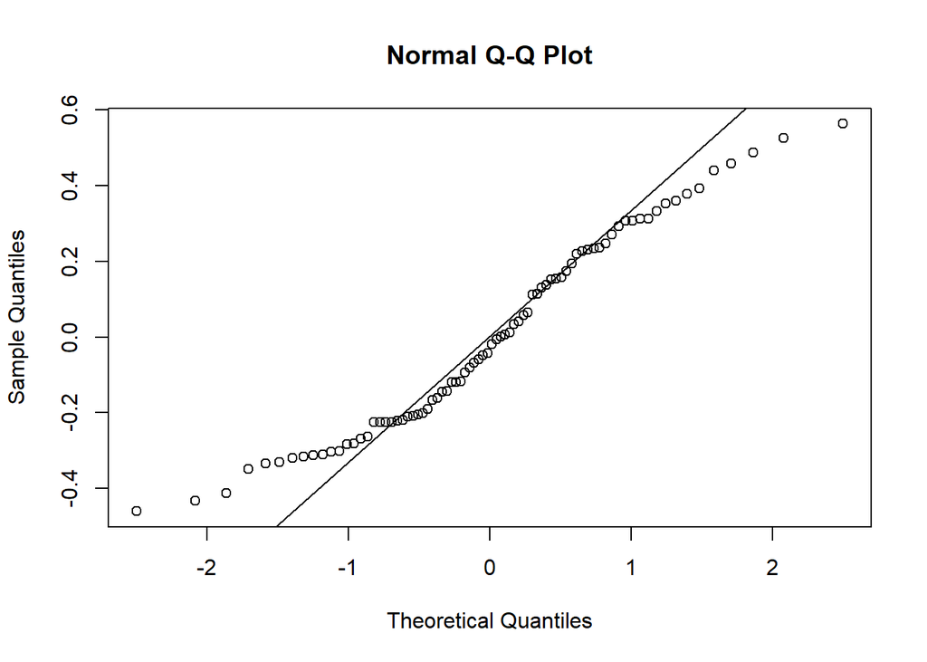

```r
qqnorm(residuals(lm_Mov2)); qqline(residuals(lm_Mov2))
```